# Algoritmos de Aprendizado de Máquina

# Sobre a base de dados

O conjunto de dados utilizado é chamado “Adult” e foi derivado do banco de dados do censo dos EUA. Foi preparado por Barry Becker a partir do censo de 1994. O propósito desse conjunto de dados é prever se uma pessoa ganha mais ou menos de US$ 50.000 por ano.

Link do conjunto de dados: https://archive.ics.uci.edu/ml/datasets/Adult

# Carregando os dados

```r
train_data <- read.csv(file = "train_data.csv")
test_data <- read.csv(file = "test_data.csv")
```

Adult Train Data - Part 1

| age | workclass | education_num | marital_status | occupation | race | sex |
| --- | --- | --- | --- | --- | --- | --- |
| 39 | 3 | 13 | 2 | 0 | 4 | 0 |
| 50 | 2 | 13 | 0 | 3 | 4 | 0 |
| 38 | 1 | 9 | 1 | 5 | 4 | 0 |
| 53 | 1 | 7 | 0 | 5 | 2 | 0 |
| 28 | 1 | 13 | 0 | 9 | 2 | 1 |

Adult Train Data - Part 2

| capital_gain | capital_loss | hours_per_week | native_country | income |
| --- | --- | --- | --- | --- |
| 2174 | 0 | 40 | 0 | 0 |
| 0 | 0 | 13 | 0 | 0 |
| 0 | 0 | 40 | 0 | 0 |
| 0 | 0 | 40 | 0 | 0 |
| 0 | 0 | 40 | 0 | 0 |

Adult Test Data - Part 1

| age | workclass | education_num | marital_status | occupation | race | sex |
| --- | --- | --- | --- | --- | --- | --- |
| 38 | 1 | 9 | 0 | 4 | 4 | 0 |
| 28 | 3 | 12 | 0 | 10 | 4 | 0 |
| 44 | 1 | 10 | 0 | 6 | 2 | 0 |
| 18 | 1 | 10 | 2 | 9 | 4 | 0 |
| 34 | 1 | 6 | 2 | 7 | 4 | 1 |

Adult Test Data - Part 2

| capital_gain | capital_loss | hours_per_week | native_country | income |
| --- | --- | --- | --- | --- |
| 0 | 0 | 50 | 0 | 0 |
| 0 | 0 | 40 | 0 | 1 |
| 7688 | 0 | 40 | 0 | 1 |
| 0 | 0 | 30 | 0 | 0 |
| 0 | 0 | 30 | 0 | 0 |

# 1. Algoritmo Baseline (Classe Majoritária)

O algoritmo baseline é um algoritmo simples que serve como referência para avaliar a eficácia de outros algoritmos. O algoritmo baseline prevê a classe majoritária em todos os casos.

```r
train_data$income_Baseline <- 0

true_negatives <- sum(train_data$income_Baseline == 0 & train_data$income == 0)
false_positives <- sum(train_data$income_Baseline == 0 & train_data$income == 1)
false_negatives <- 0
true_positives <- 0


cat("Matriz de Confusão:\n")
cat("           Previsto 0    Previsto 1\n")
cat(sprintf("Real 0:     %d            %d\n", true_negatives, false_positives))
cat(sprintf("Real 1:     %d            %d\n", false_negatives, true_positives))
```

```
## Matriz de Confusão:
```

```
##            Previsto 0    Previsto 1
```

```
## Real 0:     20873            7177
```

```
## Real 1:     0            0
```

```r
accuracy_baseline <- (true_negatives + true_positives) / length(train_data$income)
cat("Acurácia:", accuracy_baseline, "\n")
```

```
## Acurácia: 0.7441355
```

```r
if (true_positives + false_positives == 0) {
  cat("Precisão: Não definida (nenhuma previsão positiva)\n")
} else {
  precision_baseline <- true_positives / (true_positives + false_positives)
  cat("Precisão:", precision_baseline, "\n")
}
```

```
## Precisão: 0
```

```r
#calcular recall
if (true_positives + false_negatives == 0) {
  cat("Recall: Não definido (nenhum valor real positivo)\n")
} else {
  recall_baseline <- true_positives / (true_positives + false_negatives)
  cat("Recall:", recall_baseline, "\n")
}
```

```
## Recall: Não definido (nenhum valor real positivo)
```

```r
train_data$income_Baseline <- remove()
```

# 2. Definição da técnica de Validação

Foi Utilizado a técnica de validação cruzada k-fold com k = 5. A validação cruzada k-fold é uma técnica que divide o conjunto de dados em k partes iguais. Em cada iteração, uma parte é usada como conjunto de teste e as outras k-1 partes são usadas como conjunto de treinamento. O processo é repetido k vezes, de modo que cada parte é usada como conjunto de teste exatamente uma vez. O método foi utilizado para avaliar a eficácia dos algoritmos KNN, Árvore de Decisão e Redes Neurais.

# 3. Algoritmo KNN

O algoritmo KNN (K-Nearest Neighbors) é um algoritmo de aprendizado supervisionado que pode ser usado para classificação e regressão. O algoritmo KNN classifica um novo ponto de dados com base nos pontos de dados existentes que estão mais próximos a ele. O algoritmo KNN tem um parâmetro chamado k, que é o número de vizinhos mais próximos a serem considerados.

```r
if (!require(class)) install.packages("class")
library(class)

target <- train_data$income
K <- 5
folds <- cut(seq(1, nrow(train_data)), breaks=K, labels=FALSE)

accuracy_list <- c()
precision_list <- c()

# K-Fold Cross-Validation manual
for (i in 1:K) {
  test_indexes <- which(folds == i, arr.ind = TRUE)
  teste <- train_data[test_indexes, ]
  treino <- train_data[-test_indexes, ]

  # Definir os atributos preditores e a variável target
  train_features <- treino[, -ncol(treino)]
  train_labels <- treino$income
  test_features <- teste[, -ncol(teste)]
  test_labels <- teste$income

  # Aplicar o algoritmo K-NN (usando K = 5 como exemplo)
  knn_pred <- knn(train = train_features, test = test_features, cl = train_labels, k = 5)


  accuracy <- sum(knn_pred == test_labels) / length(test_labels)
  accuracy_list <- c(accuracy_list, accuracy)

  true_positives <- sum(knn_pred == 1 & test_labels == 1)
  false_positives <- sum(knn_pred == 1 & test_labels == 0)
  if (true_positives + false_positives == 0) {
    precision <- 0
  } else {
    precision <- true_positives / (true_positives + false_positives)
    precision_list <- c(precision_list, precision)
  }

  #calcular recall
  false_negatives <- sum(knn_pred == 0 & test_labels == 1)
  if (true_positives + false_negatives == 0) {
    recall <- 0
  } else {
    recall <- true_positives / (true_positives + false_negatives)
  }


  cat("Matriz de Confusão para o fold", i, ":\n")
  cat("           Previsto 0   Previsto 1\n")
  cat("Real 0:    ", sum(knn_pred == 0 & test_labels == 0), "        ", sum(knn_pred == 1 & test_labels == 0), "\n")
  cat("Real 1:    ", sum(knn_pred == 0 & test_labels == 1), "        ", sum(knn_pred == 1 & test_labels == 1), "\n\n")
}
```

```
## Matriz de Confusão para o fold 1 :
##            Previsto 0   Previsto 1
## Real 0:     3850          361
## Real 1:     598          801
##
## Matriz de Confusão para o fold 2 :
##            Previsto 0   Previsto 1
## Real 0:     3853          376
## Real 1:     566          815
##
## Matriz de Confusão para o fold 3 :
##            Previsto 0   Previsto 1
## Real 0:     3792          370
## Real 1:     591          857
##
## Matriz de Confusão para o fold 4 :
##            Previsto 0   Previsto 1
## Real 0:     3794          374
## Real 1:     579          863
##
## Matriz de Confusão para o fold 5 :
##            Previsto 0   Previsto 1
## Real 0:     3736          367
## Real 1:     614          893
```

```r
# Média das acurácias dos K folds
mean_accuracy_knn <- mean(accuracy_list)
print(paste("Acurácia média da validação cruzada:", mean_accuracy_knn))
```

```
## [1] "Acurácia média da validação cruzada: 0.829019607843137"
```

```r
# Média das precisões dos K folds
mean_precision_knn <- mean(precision_list)
print(paste("Precisão média da validação cruzada:", mean_precision_knn))
```

```
## [1] "Precisão média da validação cruzada: 0.695692987386038"
```

```r
# Média dos recalls dos K folds
mean_recall_knn <- mean(recall)
print(paste("Recall médio da validação cruzada:", mean_recall_knn))
```

```
## [1] "Recall médio da validação cruzada: 0.59256801592568"
```

# 4. Árvore de Decisão

O algoritmo de árvore de decisão é um algoritmo de aprendizado supervisionado que pode ser usado para classificação e regressão. O algoritmo de árvore de decisão divide o conjunto de dados em subconjuntos menores com base em um conjunto de regras. O algoritmo de árvore de decisão tem parâmetros que controlam a profundidade da árvore e o número mínimo de amostras necessárias para dividir um nó.

```r
if (!require(rpart)) install.packages("rpart")
library(rpart)

# Inicializar variáveis para guardar resultados
accuracy_list <- c()
precision_list <- c()

for (i in 1:K) {
  # Separar os dados em treinamento e teste
  test_indexes <- which(folds == i, arr.ind = TRUE)
  teste <- train_data[test_indexes, ]
  treino <- train_data[-test_indexes, ]

  # Definir os atributos preditores e a variável target
  train_features <- treino[, -ncol(treino)]
  train_labels <- treino$income
  test_features <- teste[, -ncol(teste)]
  test_labels <- teste$income

  # Aplicar o algoritmo Árvore de Decisão
  decision_tree <- rpart(income ~ ., data = treino, method = "class")
  rpart_pred <- predict(decision_tree, test_features, type = "class")

  accuracy <- sum(rpart_pred == test_labels) / length(test_labels)
  accuracy_list <- c(accuracy_list, accuracy)

  true_positives <- sum(rpart_pred == 1 & test_labels == 1)
  false_positives <- sum(rpart_pred == 1 & test_labels == 0)
  if (true_positives + false_positives == 0) {
    precision <- 0
  } else {
    precision <- true_positives / (true_positives + false_positives)
    precision_list <- c(precision_list, precision)
  }

  false_negatives <- sum(rpart_pred == 0 & test_labels == 1)
  if (true_positives + false_negatives == 0) {
    recall <- 0
  } else {
    recall <- true_positives / (true_positives + false_negatives)
  }

  cat("Matriz de Confusão para o fold", i, ":\n")
  cat("           Previsto 0   Previsto 1\n")
  cat("Real 0:    ", sum(rpart_pred == 0 & test_labels == 0), "        ", sum(rpart_pred == 1 & test_labels == 0), "\n")
  cat("Real 1:    ", sum(rpart_pred == 0 & test_labels == 1), "        ", sum(rpart_pred == 1 & test_labels == 1), "\n\n")
}
```

```
## Matriz de Confusão para o fold 1 :
##            Previsto 0   Previsto 1
## Real 0:     3937          274
## Real 1:     659          740
##
## Matriz de Confusão para o fold 2 :
##            Previsto 0   Previsto 1
## Real 0:     3942          287
## Real 1:     633          748
##
## Matriz de Confusão para o fold 3 :
##            Previsto 0   Previsto 1
## Real 0:     3894          268
## Real 1:     622          826
##
## Matriz de Confusão para o fold 4 :
##            Previsto 0   Previsto 1
## Real 0:     3851          317
## Real 1:     614          828
##
## Matriz de Confusão para o fold 5 :
##            Previsto 0   Previsto 1
## Real 0:     3828          275
## Real 1:     655          852
```

```r
# Média das acurácias dos K folds
mean_accuracy_DecTree <- mean(accuracy_list)
print(paste("Acurácia média da validação cruzada:", mean_accuracy_DecTree))
```

```
## [1] "Acurácia média da validação cruzada: 0.835864527629234"
```

```r
# Média das precisões dos K folds
mean_precision_DecTree <- mean(precision_list)
print(paste("Precisão média da validação cruzada:", mean_precision_DecTree))
```

```
## [1] "Precisão média da validação cruzada: 0.737329846170924"
```

```r
# Média dos recalls dos K folds
mean_recall_DecTree <- mean(recall)
print(paste("Recall médio da validação cruzada:", mean_recall_DecTree))
```

```
## [1] "Recall médio da validação cruzada: 0.565361645653616"
```

# 5. Redes Neurais

As redes neurais são um tipo de algoritmo de aprendizado de máquina que são inspirados no funcionamento do cérebro humano. As redes neurais são compostas por camadas de neurônios que são conectados entre si. Cada neurônio recebe entradas, realiza um cálculo e passa a saída para os neurônios da próxima camada. As redes neurais têm parâmetros que controlam o número de camadas, o número de neurônios em cada camada e a função de ativação.

```r
if (!require(nnet)) install.packages("nnet")
library(nnet)
train_data$income <- as.factor(train_data$income)

accuracy_list <- c()
precision_list <- c()

for (i in 1:K) {
  # Separar os dados em treinamento e teste
  test_indexes <- which(folds == i, arr.ind = TRUE)
  teste <- train_data[test_indexes, ]
  treino <- train_data[-test_indexes, ]

  # Definir os atributos preditores e a variável target
  train_features <- treino[, -ncol(treino)]
  train_labels <- treino$income
  test_features <- teste[, -ncol(teste)]
  test_labels <- teste$income

  # Aplicar o algoritmo Rede Neural
  mlp_model <- nnet(income ~ ., data = treino, size = 5, maxit = 1000)
  mlp_pred <- predict(mlp_model, test_features, type = "class")


  accuracy <- sum(mlp_pred == test_labels) / length(test_labels)
  accuracy_list <- c(accuracy_list, accuracy)
  true_positives <- sum(mlp_pred == 1 & test_labels == 1)
  false_positives <- sum(mlp_pred == 1 & test_labels == 0)
  if (true_positives + false_positives == 0) {
    precision <- 0
  } else {
    precision <- true_positives / (true_positives + false_positives)
    precision_list <- c(precision_list, precision)
  }


  false_negatives <- sum(mlp_pred == 0 & test_labels == 1)
  if (true_positives + false_negatives == 0) {
    recall <- 0
  } else {
    recall <- true_positives / (true_positives + false_negatives)
  }

  cat("Matriz de Confusão para o fold", i, ":\n")
  cat("           Previsto 0   Previsto 1\n")
  cat("Real 0:    ", sum(mlp_pred == 0 & test_labels == 0), "        ", sum(mlp_pred == 1 & test_labels == 0), "\n")
  cat("Real 1:    ", sum(mlp_pred == 0 & test_labels == 1), "        ", sum(mlp_pred == 1 & test_labels == 1), "\n\n")
}
```

```
## Matriz de Confusão para o fold 1 :
##            Previsto 0   Previsto 1
## Real 0:     3901          310
## Real 1:     605          794
##
## Matriz de Confusão para o fold 2 :
##            Previsto 0   Previsto 1
## Real 0:     3933          296
## Real 1:     616          765
##
## Matriz de Confusão para o fold 3 :
##            Previsto 0   Previsto 1
## Real 0:     4157          5
## Real 1:     1160          288
##
## Matriz de Confusão para o fold 4 :
##            Previsto 0   Previsto 1
## Real 0:     3720          448
## Real 1:     753          689
##
## Matriz de Confusão para o fold 5 :
##            Previsto 0   Previsto 1
## Real 0:     3697          406
## Real 1:     654          853
```

```r
mean_accuracy_mlp <- mean(accuracy_list)
print(paste("Acurácia média da validação cruzada:", mean_accuracy_mlp))
```

```
## [1] "Acurácia média da validação cruzada: 0.812727272727273"
```

```r
mean_precision_mlp <- mean(precision_list)
print(paste("Precisão média da validação cruzada:", mean_precision_mlp))
```

```
## [1] "Precisão média da validação cruzada: 0.741331690667302"
```

```r
mean_recall_mlp <- mean(recall)
print(paste("Recall médio da validação cruzada:", mean_recall_mlp))
```

```
## [1] "Recall médio da validação cruzada: 0.566025215660252"
```

# 6. Comparação dos Algoritmos

| Algoritmo | Resultados dos Algoritmos Acurácia | Resultados dos Algoritmos Precisão | Resultados dos Algoritmos Recall |
| --- | --- | --- | --- |
| Baseline | 0.7441 | 0.0000 | 0.0000 |
| K-NN | 0.8290 | 0.6957 | 0.5926 |
| Árvore de Decisão | 0.8359 | 0.7373 | 0.5654 |
| Rede Neural (MLP) | 0.8127 | 0.7413 | 0.5660 |

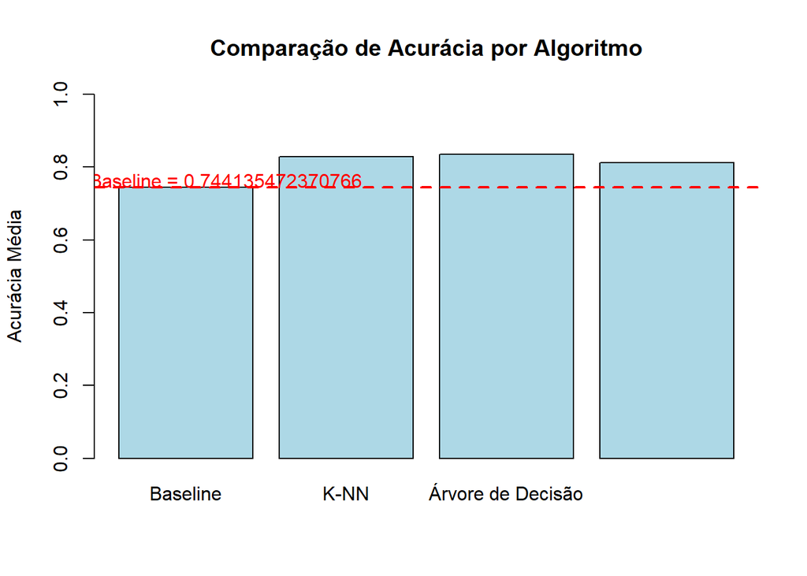

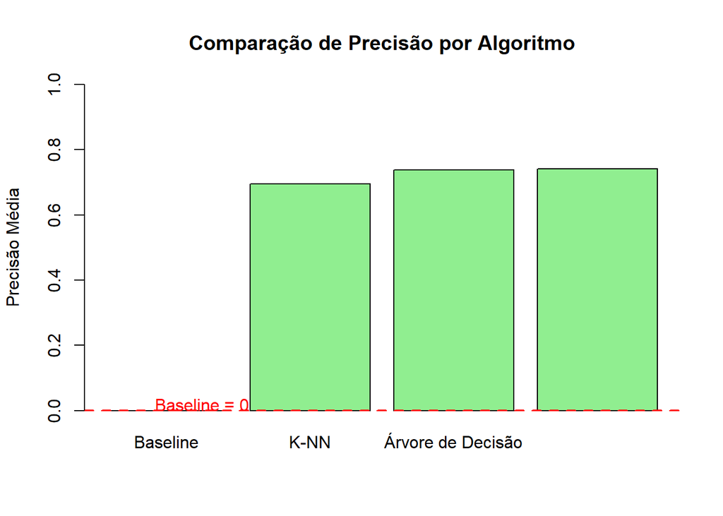

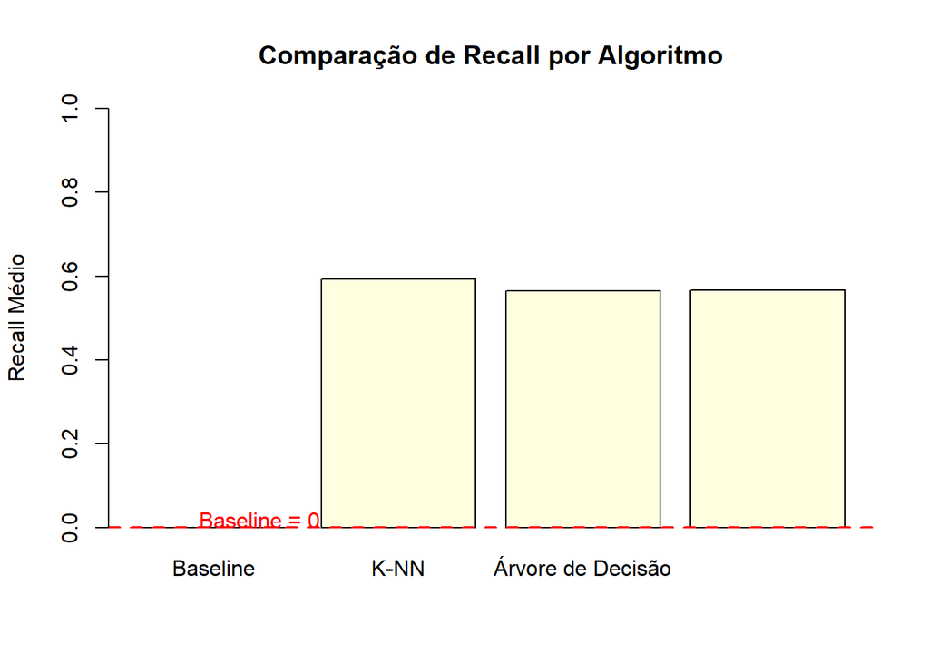